# Duel

Two duelists ($A$ and $B$) approach each other, their probability of hitting increasing over time. We may wonder when we expect the duelists to shoot.

Of course, the details are important. Are the duelists equally skilled? Do we assume a hit causes instantaneous incapacitation? How many shots does each have? Are the projectiles shot in bursts or one at a time? Do the projectiles travel slowly or infinitely fast? If the projectiles travel slowly, does a flash betray their launch? If the projectiles travel infinitely fast, can they both be fired? If all projectiles are fired, and both miss, who wins?

## Simplest assumptions

Arguably, the simplest situation involves equally skilled duelists, each with one shot, with infinitely fast projectiles that either miss or instantly incapacitate. Also, the duelists can react infinitely fast to withold shooting when the other has missed. Lastly, if both duelists pick the exact same time to shoot, a coinflip determines who actually shoots first.

Each duelist will pick a probability between 0 and 1. The duelist who picks the lower probability takes their shot at that probability. If it hits, the shooting duelist wins. If it misses, that duelist loses.

$$a = \text{probability picked by }A$$$$b = \text{probability picked by }B$$$$P(A) = \text{probability that }A\text{ wins}$$

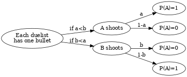

$$P(A) = \begin{cases}a & a<b \\ 1-b & b<a \\ \frac{1}{2} & a=b \end{cases}$$

It is a symmetric game, so neither can expect a better than 50% chance of winning. Thus, it is reasonable to conclude each duelist will choose a probability marginally higher than 50%. That margin will approach 0, because otherwise the other duelist could take advantage.

If $a<\frac{1}{2}$, then $B$ should be happy to let $A$ shoot first. If $a>\frac{1}{2}$, then $B$ will want to set $b$ marginally lower than $a$.

Thus, we expect the first shot to be taken when the probability is 50%.

### One magazine each (public magazine sizes)

We wish to know the critical moments (when we expect shots) if $A$ has $m$ shots and $B$ has $n$ shots, with $m$ and $n$ known to both. It is instructive to build up to this general situation. We already know that if $m=1$ and $n=1$ then each player has an equal chance of winning. The critical probability is denoted $X(1,1)=\frac{1}{2}$. The probability that $A$ wins that basic situation is denoted as $P(A,1,1)=\frac{1}{2}$, where the arguments indicate player, $m$, and $n$ respectively.

We begin with $m=2$ and $n=1$. We now use $a$ to represent the probability $A$ selects for the first shot. We will use $b$ for $B$'s selected probability. If one duelist misses, all shot selections can be reconsidered.

There are two situations to consider: $a<b$ and $b<a$. We know if $A$ misses the first shot, the game reverts to the simplest assumptions (where each player is equally likely to win). We know if $B$ misses the first shot, $A$ wins.

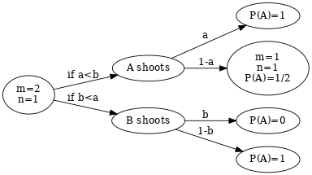

If $a<b$, then $P(A)=a+\frac{1}{2}(1-a)$, whereas if $b<a$, then $P(A)=1-b$. The critical probability occurs when each duelist is indifferent to who shoots. $$x+\frac{1}{2}(1-x) = 1-x $$

The solution, $x=\frac{1}{3}$, indicates the critical probability $X(2,1)=\frac{1}{3}$ and the probability of $A$ winning $P(A,2,1)=\frac{2}{3}$.

Next we can consider $m=3$ and $n=1$.

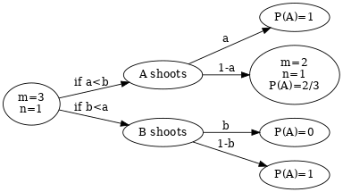

We determine the critical probability. $$x+\frac{2}{3}(1-x) = 1-x $$ $$x = \frac{1}{4} $$ $$X(3,1) = \frac{1}{4}$$ $$P(A,3,1) = \frac{3}{4}$$

This pattern continues. We can prove that $X(m,n)=\frac{1}{m+n}$ and $P(A,m,n)=\frac{m}{m+n}$. We do so by first assuming $P(A,m-1,n)=\frac{m-1}{m+n-1}$ and $P(A,m,n-1)=\frac{m}{m+n-1}$.

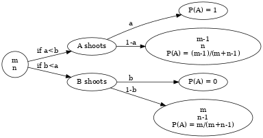

Thus, to determine the critical probability: $$x+\frac{m-1}{m+n-1}(1-x)=\frac{m}{m+n-1}(1-x)$$

```python
reset()
var("x m n")
eq2 = (x+(m-1)/(m+n-1)*(1-x)==m/(m+n-1)*(1-x))
show(solve(eq2,x))
```

$$\newcommand{\Bold}[1]{\mathbf{#1}}\left[x = \frac{1}{m + n}\right]$$

```python
(m/(m+n-1)*(1-x)).substitute(x==1/(m+n)).simplify_full()
```

```
m/(m + n)
```

$$P(A,m,n)=\frac{m}{m+n}$$

### Private, random magazine (0 or 1 bullet)

Each duelist either has 0 or 1 bullets. The probability that $A$ has a bullet is $r$, and $B$'s probability is $s$, and these probabilities are independent. Each duelist decides when they will shoot their bullet (if they have one); these times are $a$ and $b$ as above.

If the duelist who selected an earlier time has no bullet, then the other duelist either recognizes this or not. You could imagine the blanks/duds involved, such that the duelists themselves don't even know. A blank could make a bang whereas the dud's inaction could be hidden.

We also need to consider what happens if no bullets hit. It will be assumed the duel results in a melee fight that each is equally likely to win.

### Blanks

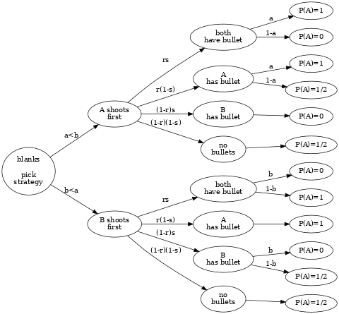

$$rsx+r(1-s)x+\frac{1}{2}r(1-s)(1-x) = rs(1-x)+r(1-s)+\frac{1}{2}(1-r)s(1-x)$$

```python
reset()
var("r s x")
eq = (r*s*x+r*(1-s)*x+1/2*r*(1-s)*(1-x)==r*s*(1-x)+r*(1-s)+1/2*(1-r)*s*(1-x))
xx = solve(eq,x)[0].rhs()
show(solve(eq,x)[0])
```

$$\newcommand{\Bold}[1]{\mathbf{#1}}x = \frac{r + s}{{\left(2 \, r + 1\right)} s + r}$$

$$x=\frac{r+s}{2rs+r+s}$$

```python
show((r*s*x+r*(1-s)*x+1/2*r*(1-s)*(1-x)+1/2*(1-r)*(1-s)).substitute(x=(r+s)/(2*r*s+r+s)).expand())
```

$$\newcommand{\Bold}[1]{\mathbf{#1}}\frac{r^{2} s}{2 \, {\left(2 \, r s + r + s\right)}} + \frac{r s^{2}}{2 \, {\left(2 \, r s + r + s\right)}} + \frac{r^{2}}{2 \, {\left(2 \, r s + r + s\right)}} + \frac{r s}{2 \, {\left(2 \, r s + r + s\right)}} - \frac{1}{2} \, s + \frac{1}{2}$$

$$P(A)=\frac{r^{2} s}{2 \, {\left(2 \, r s + r + s\right)}} + \frac{r s^{2}}{2 \, {\left(2 \, r s + r + s\right)}} + \frac{r^{2}}{2 \, {\left(2 \, r s + r + s\right)}} + \frac{r s}{2 \, {\left(2 \, r s + r + s\right)}} - \frac{1}{2} \, s + \frac{1}{2}$$

### Duds

The analysis is more difficult with duds.

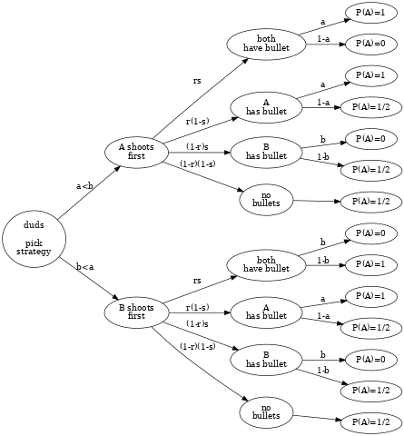

If $a<b$, then $$P(A)=rsa+r(1-s)a+r(1-s)(1-a)/2+(1-r)s(1-b)/2+(1-r)(1-s)/2$$ If $b<a$, then $$P(A)=rs(1-b)+r(1-s)a+r(1-s)(1-a)/2+(1-r)s(1-b)/2+(1-r)(1-s)/2$$

If $b$ is too high, then $a$ should be set marginally below. If $b$ is too low, then $a$ should be 1. Taking these responses into account...

If $c<b$, then $$P(A)=rsb+r(1-s)b+r(1-s)(1-b)/2+(1-r)s(1-b)/2+(1-r)(1-s)/2$$ If $b<c$, then $$P(A)=rs(1-b)+r(1-s)(1)+r(1-s)(1-1)/2+(1-r)s(1-b)/2+(1-r)(1-s)/2$$

We may determine the value of $b$ that produces equality.

```python
reset()
var("a b r s")
pa1 = r*s*b+r*(1-s)*b+r*(1-s)*(1-b)/2+(1-r)*s*(1-b)/2+(1-r)*(1-s)/2
pa2 = r*s*(1-b)+r*(1-s)*1+r*(1-s)*(1-1)/2+(1-r)*s*(1-b)/2+(1-r)*(1-s)/2
sol = solve(pa1==pa2,b)[0]
show(sol)
show(pa1.substitute(sol).simplify_full())
show(pa2.substitute(sol).simplify_full())
```

$$\newcommand{\Bold}[1]{\mathbf{#1}}b = \frac{s + 1}{3 \, s + 1}$$

$$\newcommand{\Bold}[1]{\mathbf{#1}}-\frac{{\left(r + 1\right)} s^{2} - 2 \, {\left(r + 1\right)} s - r - 1}{2 \, {\left(3 \, s + 1\right)}}$$

$$\newcommand{\Bold}[1]{\mathbf{#1}}-\frac{{\left(r + 1\right)} s^{2} - 2 \, {\left(r + 1\right)} s - r - 1}{2 \, {\left(3 \, s + 1\right)}}$$

$$b=\frac{s+1}{3s+1}$$

Fascinating, the critical strategy for $B$ is independent of $r$? But, if $r=0$, then $b$ should be 1, independent of $s$... so instead...

```python
reset()
var("a b r s")
pa1 = r*s*b+r*(1-s)*b+r*(1-s)*(1-b)/2+(1-r)*s*(1-b)/2+(1-r)*(1-s)/2
pa2 = r*s*(1-b)+r*(1-s)*1+r*(1-s)*(1-1)/2+(1-r)*s*(1-b)/2+(1-r)*(1-s)/2
show(derivative(pa1,b).expand())
show(derivative(pa2,b).expand())
```

$$\newcommand{\Bold}[1]{\mathbf{#1}}r s + \frac{1}{2} \, r - \frac{1}{2} \, s$$

$$\newcommand{\Bold}[1]{\mathbf{#1}}-\frac{1}{2} \, r s - \frac{1}{2} \, s$$

When $b$ is less than $c$, it always makes sense to increase it. But, when $b$ is larger than $c$, it sometimes makes sense for $b\to1$ and other times $b\to c$, depending on the relative values of $r$ and $s$. If $\left(rs+\frac{r-s}{2}\right)$ is positive, then $b$ should be $c=\frac{s+1}{3s+1}$, and if $\left(rs+\frac{r-s}{2}\right)$ is negative, then $b$ should be 1.

# Possible continuations

- Uneven skill between duelists
- Larger private random magazines
- Private burst sizes
- More combatants (free-for-all or teams)